# Lab 03 - Week 2 Monday

Yunting Chiu

2021-05-28

These sets of labs will introduce you to logistic regression. This will also be your first introduction to the [rsample](https://rsample.tidymodels.org/) package which we will use to perform train-test split.

# Exercise 1

In this exercise we will explore the `mlc_churn` data set included in **tidymodels**.

```r
suppressPackageStartupMessages(library(tidyverse))
suppressPackageStartupMessages(library(tidymodels))
data("mlc_churn")

# know the Customer churn data in advance
help("mlc_churn")
```

The data set contains a variable called `churn`

- We will be modeling customer churn. Before we go over the questions, let’s take a look at what’s going on in the response variable `churn`. In the graph below, we can see that many customers gave negative feedback rather than positive feedback.

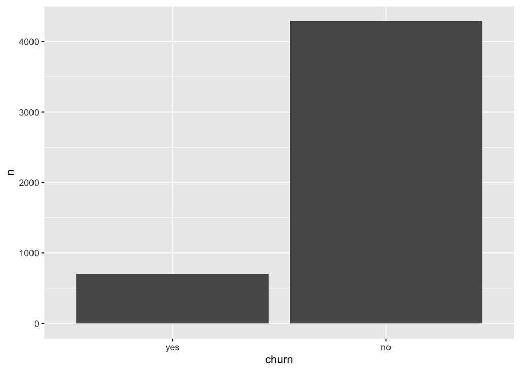

```r
mlc_churn %>%
  count(churn) %>%
  ggplot(aes(churn, n)) +
  geom_col()
```

1. Create a test-train `rsplit` object of `mlc_churn` using `initial_split()`. Use the arguments to set the proportions of the training data to be 80%. Stratify the sampling according to the `churn` variable. How many observations are in the testing and training sets?
- Ideally, we would divide the data into 75-80% for training and 25%-30% for testing. We are going to take 80 % training data and take 20 % testing data in this exercise.
- There are 4001 observations in the training sets, and 999 observations in the testing sets. Totally the data frame has 5000 observations.

```r
set.seed(1) # Ensure that the data can be samely separated into the same observations.
mlc_split <- initial_split(mlc_churn, prop = 0.8, strata = churn)
mlc_split
```

```
## <Analysis/Assess/Total>
## <4001/999/5000>
```

2. Create the training and testing data set with `training()` and `testing()` respectively. Does the observation counts match what you found in the last question?
- Using `nrow()`, we can exactly see the training and testing sets have 4001 and 999, respectively.

```r
mlc_training <- training(mlc_split)
nrow(mlc_training)
```

```
## [1] 4001
```

```r
mlc_testing <- testing(mlc_split)
nrow(mlc_testing)
```

```
## [1] 999
```

3. Fit a logistic regression model using `logistic_reg()`. Use `number_vmail_messages, total_intl_minutes, total_intl_calls, total_intl_charge, number_customer_service_calls` as predictors. Remember to fit the model only using the training data set.

```r
mlc_formula <- churn ~ number_vmail_messages + total_intl_minutes + total_intl_calls + total_intl_charge + number_customer_service_calls

# set a engine as logistic regression
lr_spec <- logistic_reg() %>%
  set_engine("glm") %>%
  set_mode("classification")

lr_spec %>%
  fit(mlc_formula, data = mlc_training) -> lr_fit
```

4. Inspect the model with `summary()` and `tidy()`. How good are the variables we have chosen?

It can be seen that only 3 out of the 5 predictors are significantly associated to the outcome. With the small p-value, the significant predictors are `number_vmail_messages`, `total_intl_calls`, and `number_customer_service_calls`. The logistic regression coefficients represent the change in the log odds of the outcome for each unit increase in the predictor variable.

```r
# using summary()
lr_fit %>%
  pluck("fit") %>% # unest the list
  summary()
```

```
##
## Call:
## stats::glm(formula = churn ~ number_vmail_messages + total_intl_minutes +
##     total_intl_calls + total_intl_charge + number_customer_service_calls,
##     family = stats::binomial, data = data)
##
## Deviance Residuals:
##     Min       1Q   Median       3Q      Max
## -2.7805   0.3518   0.4614   0.5777   1.4428
##
## Coefficients:
##                                Estimate Std. Error z value Pr(>|z|)
## (Intercept)                    2.875577   0.221515  12.981  < 2e-16 ***
## number_vmail_messages          0.023680   0.004096   5.782  7.4e-09 ***
## total_intl_minutes            -1.347891   4.454241  -0.303 0.762188
## total_intl_calls               0.069261   0.021027   3.294 0.000988 ***
## total_intl_charge              4.730498  16.497912   0.287 0.774317
## number_customer_service_calls -0.434863   0.032924 -13.208  < 2e-16 ***
## ---
## Signif. codes:  0 '***' 0.001 '**' 0.01 '*' 0.05 '.' 0.1 ' ' 1
##
## (Dispersion parameter for binomial family taken to be 1)
##
##     Null deviance: 3261.7  on 4000  degrees of freedom
## Residual deviance: 3020.6  on 3995  degrees of freedom
## AIC: 3032.6
##
## Number of Fisher Scoring iterations: 5
```

Note:

1. Null deviance: It shows how well the response variable is predicted by a model that includes only intercept.
2. Residual deviance: It shows how well the response variable is predicted by a model that include all independent variables.
3. AIC: AIC provides a method for assessing the quality of your model through comparison of related models. Small value of AIC is better.

```r
# using tidy()
tidy(lr_fit)
```

```
## # A tibble: 6 x 5
##   term                          estimate std.error statistic  p.value
##   <chr>                            <dbl>     <dbl>     <dbl>    <dbl>
## 1 (Intercept)                     2.88     0.222      13.0   1.56e-38
## 2 number_vmail_messages           0.0237   0.00410     5.78  7.40e- 9
## 3 total_intl_minutes             -1.35     4.45       -0.303 7.62e- 1
## 4 total_intl_calls                0.0693   0.0210      3.29  9.88e- 4
## 5 total_intl_charge               4.73    16.5         0.287 7.74e- 1
## 6 number_customer_service_calls  -0.435    0.0329    -13.2   7.86e-40
```

## Reference

```r
predict(lr_fit, new_data = mlc_testing) %>% # using reg model and testing dataset for testing
  head()
```

```
## # A tibble: 6 x 1
##   .pred_class
##   <fct>
## 1 no
## 2 no
## 3 no
## 4 no
## 5 no
## 6 no
```

- We can also get probability predictions by using `type = "prob"` in `predict()`.

```r
predict(lr_fit, new_data = mlc_testing, type = "prob") %>%
  head()
```

```
## # A tibble: 6 x 2
##   .pred_yes .pred_no
##       <dbl>    <dbl>
## 1    0.260     0.740
## 2    0.0831    0.917
## 3    0.0541    0.946
## 4    0.0836    0.916
## 5    0.0927    0.907
## 6    0.149     0.851
```

- `augment()` can automatically add the `.pred_class` and the probability of yes and no, and add in the existing data frame as new columns.

```r
preds <- augment(lr_fit, new_data = mlc_testing)
preds %>%
  names()
```

```
##  [1] "state"                         "account_length"
##  [3] "area_code"                     "international_plan"
##  [5] "voice_mail_plan"               "number_vmail_messages"
##  [7] "total_day_minutes"             "total_day_calls"
##  [9] "total_day_charge"              "total_eve_minutes"
## [11] "total_eve_calls"               "total_eve_charge"
## [13] "total_night_minutes"           "total_night_calls"
## [15] "total_night_charge"            "total_intl_minutes"
## [17] "total_intl_calls"              "total_intl_charge"
## [19] "number_customer_service_calls" "churn"
## [21] ".pred_class"                   ".pred_yes"
## [23] ".pred_no"
```

```r
preds %>%
  conf_mat(truth = churn, estimate = .pred_class) -> confusionMatrix
confusionMatrix
```

```
##           Truth
## Prediction yes  no
##        yes  10   2
##        no  131 856
```

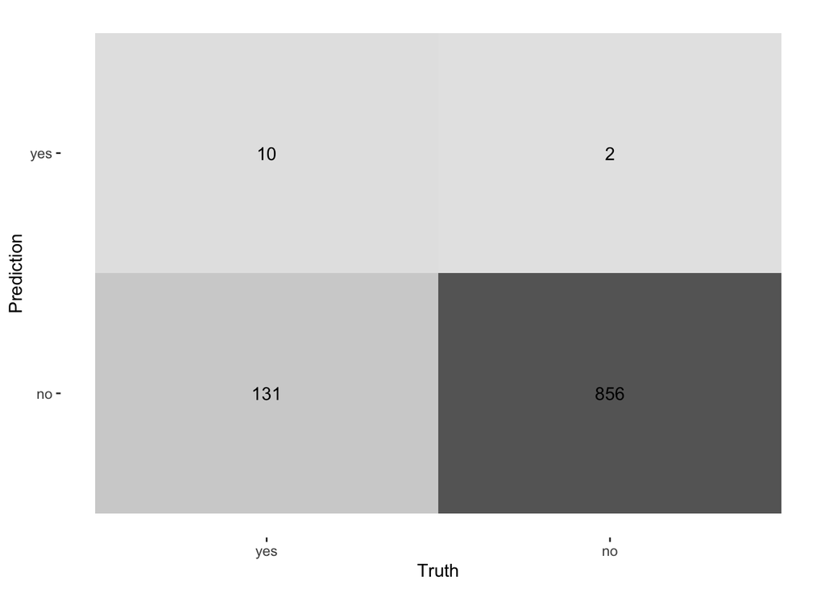

```r
# we can also plot the confusion matrix
confusionMatrix %>%
  autoplot(type = "heatmap")
```

- The `accuracy()`is useful for demonstrating the correct percentage of model prediction. So we know the logistic regression model has 87 % accuracy for predicting the customer churn, which can persuade that is a good model again.

```r
preds %>%
accuracy(truth = churn, estimate = .pred_class)
```

```
## # A tibble: 1 x 3
##   .metric  .estimator .estimate
##   <chr>    <chr>          <dbl>
## 1 accuracy binary         0.867
```

```r
# preds %>%
#   mutate(.pred_class_40 = ifelse(.pred_no > 0.4, 'no', 'yes')) %>%
#   mutate(.pred_class_40 = as.factor(.pred_class_40)) %>%
#   conf_mat(estimate = .pred_class_40, truth = churn) %>%
#   autoplot(type = "heatmap")
```